# Curvilinear/Polynomial Regression

Chetana Jamadar

2022-12-19

###################Introduction##################

Curvilinear regression is the name given to any regression model that attempts to fit a curve as opposed to a straight line.

Common examples of curvilinear regression models include:

Quadratic Regression: Used when a quadratic relationship exists between a predictor variable and a response variable.

Q1. Table 3 presents the data concerning the strength of Kraft paper and the % of hardwood in the batch of pulp from which the paper was produced. Show that the quadratic model appears to provide a good fit to the relationship between tensile strength and hardwood concentration.

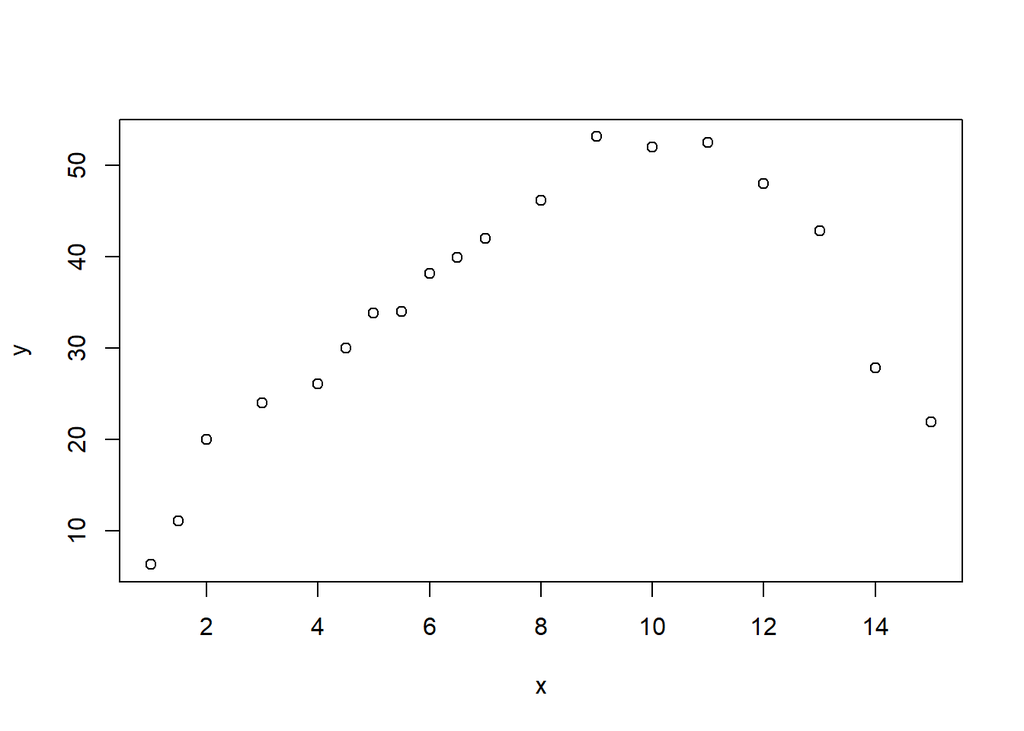

```r
y=c(6.3,11.1,20,24,26.1,30,33.8,34,38.1,39.9,42,46.1,53.1,
52,52.5,48,42.8,27.8,21.9)
x=c(1,1.5,2,3,4,4.5,5,5.5,6,6.5,7,8,9,10,11,12,13,14,15)
plot(x,y)
```

```r
Model_1=lm(y~x+I(x^2))
Model_1
```

```
##
## Call:
## lm(formula = y ~ x + I(x^2))
##
## Coefficients:
## (Intercept)            x       I(x^2)
##     -6.6742      11.7640      -0.6345
```

```r
#y=-6.6742+11.7640( x )+(-0.6345) I(x^2)
summary(Model_1)
```

```
##
## Call:
## lm(formula = y ~ x + I(x^2))
##
## Residuals:
##     Min      1Q  Median      3Q     Max
## -5.8503 -3.2482 -0.7267  4.1350  6.5506
##
## Coefficients:
##             Estimate Std. Error t value Pr(>|t|)
## (Intercept) -6.67419    3.39971  -1.963   0.0673 .
## x           11.76401    1.00278  11.731 2.85e-09 ***
## I(x^2)      -0.63455    0.06179 -10.270 1.89e-08 ***
## ---
## Signif. codes:  0 '***' 0.001 '**' 0.01 '*' 0.05 '.' 0.1 ' ' 1
##
## Residual standard error: 4.42 on 16 degrees of freedom
## Multiple R-squared:  0.9085, Adjusted R-squared:  0.8971
## F-statistic: 79.43 on 2 and 16 DF,  p-value: 4.912e-09
```

```r
#centering the data
x_1=x-mean(x)
x_2=(x-mean(x))^2
Model_2=lm(y~x_1+I(x_2))
summary(Model_2)
```

```
##
## Call:
## lm(formula = y ~ x_1 + I(x_2))
##
## Residuals:
##     Min      1Q  Median      3Q     Max
## -5.8503 -3.2482 -0.7267  4.1350  6.5506
##
## Coefficients:
##             Estimate Std. Error t value Pr(>|t|)
## (Intercept) 45.29497    1.48287   30.55 1.29e-15 ***
## x_1          2.54634    0.25384   10.03 2.63e-08 ***
## I(x_2)      -0.63455    0.06179  -10.27 1.89e-08 ***
## ---
## Signif. codes:  0 '***' 0.001 '**' 0.01 '*' 0.05 '.' 0.1 ' ' 1
##
## Residual standard error: 4.42 on 16 degrees of freedom
## Multiple R-squared:  0.9085, Adjusted R-squared:  0.8971
## F-statistic: 79.43 on 2 and 16 DF,  p-value: 4.912e-09
```

```r
library(car)
vif(Model_1)
```

```
##        x   I(x^2)
## 17.12077 17.12077
```

```r
vif(Model_2)
```

```
##     x_1  I(x_2)
## 1.09705 1.09705
```

```r
#These vifs are much larger than those for the centred data.Thus centering the linear terms #in a polynomial model removes some of nonessential ill-conditionaled by the choice
#of origin for the regressor.
```

2. Fit the regression model as specified below for the data given in Table 2 y = β0 +β1x1 +β2x2 +β11x21 +β22x2^2 +β12x1x2
1. Compute t-statistic for each model parameter and conclude on the significance of corresponding regression parameter.
2. Use extra sum of squares method to evaluate the contribution of all the quadratic terms x21 x22 and x1x2 in regression sum of squares for the regression model fitted in (a). Also test itssignificance.
3. Plot the residuals versus fitted values. Also have the Box plot of residuals to check the existence of any of the outlying observations.

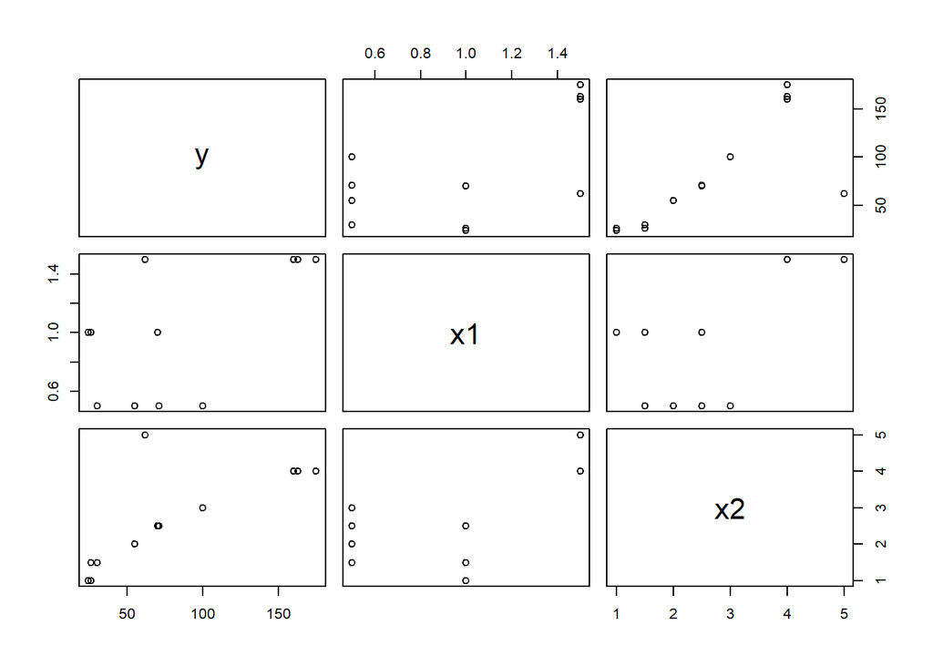

```r
y=c(26,24,175,160,163,55,62,100,26,30,70,71)
x1=c(1,1,1.5,1.5,1.5,0.5,1.5,0.5,1,0.5,1,0.5)
x2=c(1,1,4,4,4,2,5,3,1.5,1.5,2.5,2.5)
d=data.frame(y,x1,x2)
plot(d)
```

```r
fit=lm(y~x1+x2+I(x1^2)+I(x2^2)+I(x1*x2))
fit
```

```
##
## Call:
## lm(formula = y ~ x1 + x2 + I(x1^2) + I(x2^2) + I(x1 * x2))
##
## Coefficients:
## (Intercept)           x1           x2      I(x1^2)      I(x2^2)   I(x1 * x2)
##       17.38      -487.68       158.57       422.05       -16.74       -72.78
```

```r
summary(fit)
```

```
##
## Call:
## lm(formula = y ~ x1 + x2 + I(x1^2) + I(x2^2) + I(x1 * x2))
##
## Residuals:
##      Min       1Q   Median       3Q      Max
## -16.7756  -3.0540   0.8669   5.2341   9.6960
##
## Coefficients:
##             Estimate Std. Error t value Pr(>|t|)
## (Intercept)    17.38      45.88   0.379 0.717871
## x1           -487.68      90.38  -5.396 0.001671 **
## x2            158.57      15.95   9.943 5.98e-05 ***
## I(x1^2)       422.05      65.95   6.399 0.000686 ***
## I(x2^2)       -16.73       3.44  -4.866 0.002807 **
## I(x1 * x2)    -72.78      19.89  -3.659 0.010588 *
## ---
## Signif. codes:  0 '***' 0.001 '**' 0.01 '*' 0.05 '.' 0.1 ' ' 1
##
## Residual standard error: 10.45 on 6 degrees of freedom
## Multiple R-squared:  0.9814, Adjusted R-squared:  0.9659
## F-statistic: 63.41 on 5 and 6 DF,  p-value: 4.117e-05
```

```r
aov(fit)
```

```
## Call:
##    aov(formula = fit)
##
## Terms:
##                        x1        x2   I(x1^2)   I(x2^2) I(x1 * x2) Residuals
## Sum of Squares  11552.000  9287.202  2311.250 10041.658   1463.716   655.841
## Deg. of Freedom         1         1         1         1          1         6
##
## Residual standard error: 10.45499
## Estimated effects may be unbalanced
```

```r
ss_res_FM=655.841
ms_res_FM=ss_res_FM/6
fit1=lm(y~x1+x2)
fit1
```

```
##
## Call:
## lm(formula = y ~ x1 + x2)
##
## Coefficients:
## (Intercept)           x1           x2
##      -14.64        19.57        28.21
```

```r
aov(fit1)
```

```
## Call:
##    aov(formula = fit1)
##
## Terms:
##                        x1        x2 Residuals
## Sum of Squares  11552.000  9287.202 14472.464
## Deg. of Freedom         1         1         9
##
## Residual standard error: 40.10052
## Estimated effects may be unbalanced
```

```r
summary(fit1)
```

```
##
## Call:
## lm(formula = y ~ x1 + x2)
##
## Residuals:
##     Min      1Q  Median      3Q     Max
## -93.786  -7.884  -1.018  23.268  47.429
##
## Coefficients:
##             Estimate Std. Error t value Pr(>|t|)
## (Intercept)   -14.64      31.61  -0.463   0.6542
## x1             19.57      36.82   0.532   0.6079
## x2             28.21      11.74   2.403   0.0397 *
## ---
## Signif. codes:  0 '***' 0.001 '**' 0.01 '*' 0.05 '.' 0.1 ' ' 1
##
## Residual standard error: 40.1 on 9 degrees of freedom
## Multiple R-squared:  0.5902, Adjusted R-squared:  0.4991
## F-statistic:  6.48 on 2 and 9 DF,  p-value: 0.01806
```

```r
ss_res_RM=14472.464
SSH=ss_res_RM-ss_res_FM
f=(SSH/3)/ms_res_FM
f
```

```
## [1] 42.13406
```

```r
f_tab=qf(0.05,3,6,lower.tail = F)
f_tab
```

```
## [1] 4.757063
```

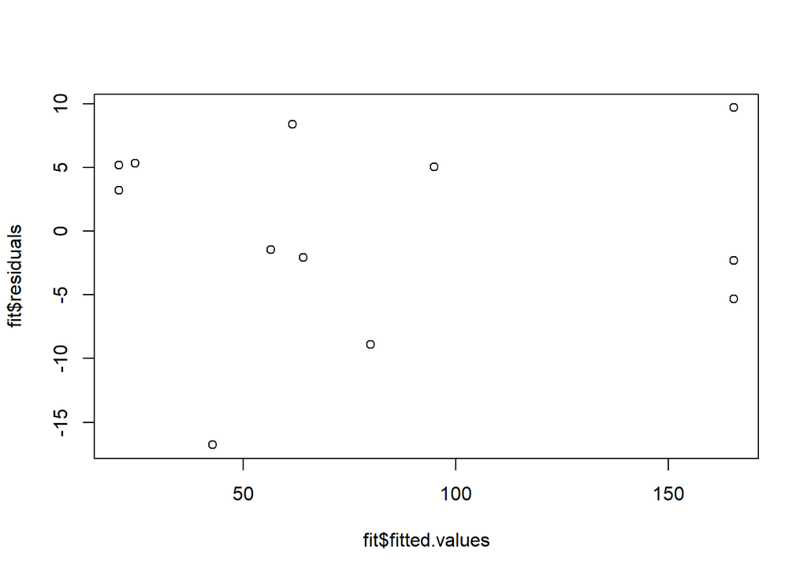

```r
plot(fit$fitted.values,fit$residuals)
```

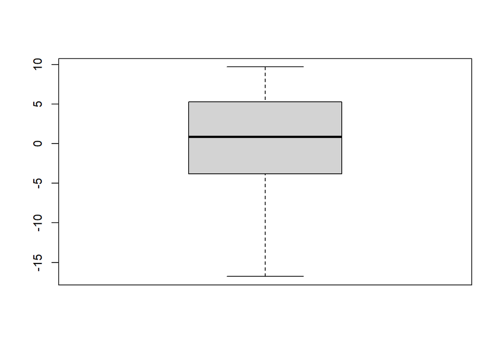

```r
boxplot(fit$residuals)
```

```r
#to find staderdised residuals
rstandard(fit)
```

```
##          1          2          3          4          5          6          7
##  0.6636819  0.4084160  1.1348982 -0.6208268 -0.2696818 -0.1701910 -2.0107194
##          8          9         10         11         12
##  0.9570321 -1.8718754  0.8744072  2.0822018 -1.0116445
```

```r
#studentised residual
rstudent(fit)
```

```
##          1          2          3          4          5          6          7
##  0.6293991  0.3781241  1.1690659 -0.5858643 -0.2476905 -0.1557387 -3.2139584
##          8          9         10         11         12
##  0.9490846 -2.6493081  0.8545221  3.6088955 -1.0140226
```

```r
#press residual
e=fit$residuals
h=hatvalues(fit)
e_=e/(1-h)
```